# Project Writeup

Eli Hawes

2025-03-07

# Introduction

I am using a AI / Machine Learning salaries dataset from Kaggle with 10 columns and 73,148 rows. Link to dataset: https://www.kaggle.com/datasets/cedricaubin/ai-ml-salaries?resource=download

### Variable descriptions:

###### work_year is the year in which the salary was paid

###### experience_level is how long they have worked at that job (or in the field), Entry level, Mid level, Senior, and Executive.

###### employment_type is the sort of employment / contract an employee has with their company

###### job_title lists the specific title / position of each given employee

###### salary represents their gross annual salary

###### salary_in_usd is the annual salary in usd

###### salary_currency is the currency in which the salary variable is described, before being converted to usd

###### employee_residence tells us where each employee lived the year the data was collected

###### remote_ratio is the amount of work each employee does remotely / virtually, in percentage (100 means fully virtual)

###### company_size is the amount of people that worked at the company each person was employed by, ranging from small, S (<50) to large, L (>250). 50-250 is Medium.

###### company_location is the country in which the employer’s main office is for each given employee.

Each observation in this dataset represents a different employee, and their relevant data.

### Why this data?

I am working with data regarding salaries of data science (specifically AI / Machine Learning) jobs, as I intend to go into the machine learning / neural networking sub-branch of data science. These salaries, therefore, are likely relevant or related to my direct future. Plus, it’s interesting looking at salary trends compared to trends in the cost of living (if not a bit depressing)

### Summary statistics

Mean, median, standard deviation, and range:

```r
mean(salary_data$salary_in_usd)
```

```
## [1] 158013.7
```

```r
median(salary_data$salary_in_usd)
```

```
## [1] 147500
```

```r
sd(salary_data$salary_in_usd)
```

```
## [1] 72501.3
```

```r
max(salary_data$salary_in_usd) - min(salary_data$salary_in_usd)
```

```
## [1] 785000
```

```r
#Range of 785,000 is from $15,000 to $800,000
```

# Visualization

Two quantitative variables:

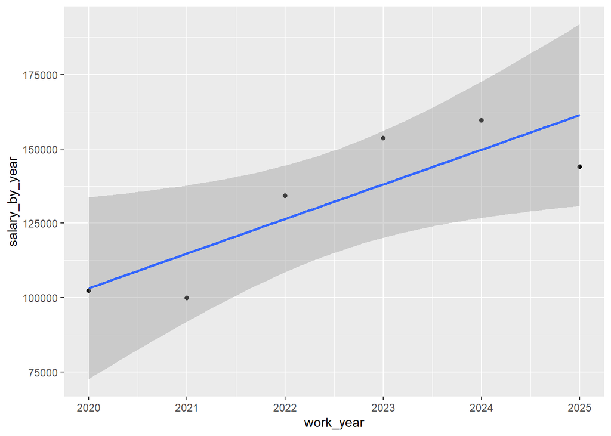

```r
salary_data %>%
  group_by(work_year) %>%
  summarize(salary_by_year = mean(salary_in_usd)) %>%
  ggplot(aes(work_year,salary_by_year)) +
  geom_point() +
  geom_smooth(method = 'lm')
```

Showing the relationship between two quantitative variables is difficult for me, since this data set has very few quantitative variables. The best options I have are between salary (in usd) and year, or between salary (in usd) and salary (in a variety of currencies). Between those two, the pick is year, even though it is really more of a categorical. That being said, we can see a general upwards trend in annual salary, but less change in the projected minimum than the projected maximum. This may reflect the reality that entry-level data science jobs have not really increased their pay, but that more experienced positions may be getting paid more (or just executives…).

A categorical and a quantitative (also, I think, my most interesting and relevant plot):

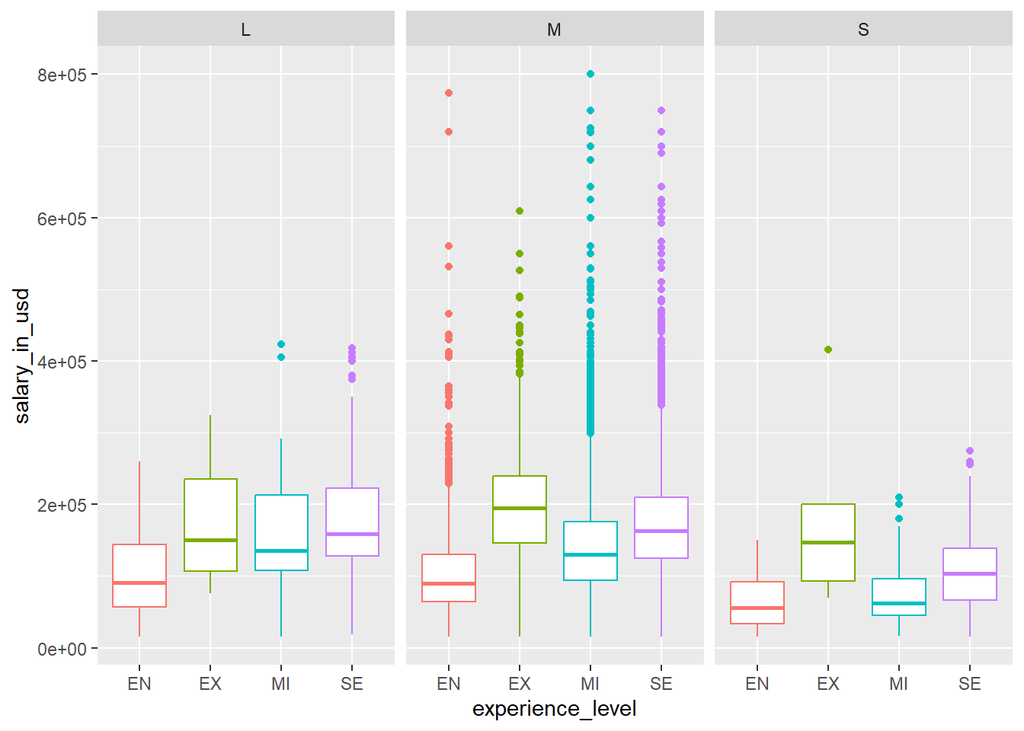

```r
ggplot(salary_data, aes(experience_level, salary_in_usd, color = experience_level)) +
  facet_wrap(~company_size) +
  theme(legend.position="none") +
  geom_boxplot()
```

This graph is a mess. The company sizes are out of order, the experience levels are out of order, and it just generally doesn’t make a lot of sense / isn’t very coherent. Below, there is an improved version which I expand upon further.

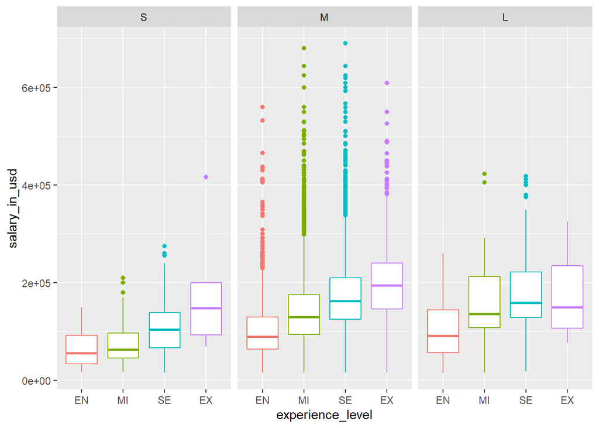

```r
salary_data$experience_level <- factor(salary_data$experience_level, levels=c("EN", "MI", "SE", "EX"))
salary_data$company_size <- factor(salary_data$company_size, levels = c("S","M", "L"))
salary_data <- filter(salary_data, salary_in_usd < 700000)
ggplot(salary_data, aes(experience_level, salary_in_usd, color = experience_level)) +
  facet_wrap(~company_size) +
  theme(legend.position="none") +
  geom_boxplot()
```

# Statistical analyses

```r
cor.test(salary_data$salary_in_usd, salary_data$work_year, method="pearson")
```

```
##
##  Pearson's product-moment correlation
##
## data:  salary_data$salary_in_usd and salary_data$work_year
## t = 17.824, df = 73099, p-value < 2.2e-16
## alternative hypothesis: true correlation is not equal to 0
## 95 percent confidence interval:
##  0.05856167 0.07299726
## sample estimates:
##        cor
## 0.06578291
```

```r
cor.test(salary_data$salary_in_usd, salary_data$work_year, method="spearman")
```

```
##
##  Spearman's rank correlation rho
##
## data:  salary_data$salary_in_usd and salary_data$work_year
## S = 6.2534e+13, p-value < 2.2e-16
## alternative hypothesis: true rho is not equal to 0
## sample estimates:
##        rho
## 0.03949477
```

In addition to the correlation coefficients, I ran a linear regression analysis on the same variables to see how much of the change in mean salary was explained by the year, after determining that they were correlated (even if they aren’t correlated meaningfully).

```r
salaries_regression <- lm(salary_in_usd ~ work_year, data = salary_data)
summary(salaries_regression)
```

```
##
## Call:
## lm(formula = salary_in_usd ~ work_year, data = salary_data)
##
## Residuals:
##     Min      1Q  Median      3Q     Max
## -153743  -50001   -9512   40699  530699
##
## Coefficients:
##               Estimate Std. Error t value Pr(>|t|)
## (Intercept) -1.965e+07  1.111e+06  -17.68   <2e-16 ***
## work_year    9.789e+03  5.492e+02   17.82   <2e-16 ***
## ---
## Signif. codes:  0 '***' 0.001 '**' 0.01 '*' 0.05 '.' 0.1 ' ' 1
##
## Residual standard error: 70920 on 73099 degrees of freedom
## Multiple R-squared:  0.004327,   Adjusted R-squared:  0.004314
## F-statistic: 317.7 on 1 and 73099 DF,  p-value: < 2.2e-16
```

Lastly, I did a t-test between remote ratio and salary (with remote ratio as the independant variable, of course), to try and determine the difference between in-person and virtual employee’s mean salaries.

```r
salary_data <- filter(salary_data, remote_ratio %in% c("0", "100"))
t.test(salary_in_usd ~ remote_ratio, data = salary_data)
```

```
##
##  Welch Two Sample t-test
##
## data:  salary_in_usd by remote_ratio
## t = 20.594, df = 29058, p-value < 2.2e-16
## alternative hypothesis: true difference in means between group 0 and group 100 is not equal to 0
## 95 percent confidence interval:
##  10753.92 13016.26
## sample estimates:
##   mean in group 0 mean in group 100
##          160490.9          148605.8
```

This t-test was quite interesting to me, because I went into it with the assumption that they would have differing means, and the results do seem to indicate that (since the true difference in means is not zero), but I initially read it as there was no true difference in means and was shocked. After all, my hypothesis was wrong, and I am left with the somewhat dissapointing (yet sensible) reality that virtual employees are payed less, on average, than in-person employees.

For the purpose of this t-test, I had to cut out the hybrid workers, but it would be interesting to test more regarding the relationships between hybrid/virtual and hybrid/in-person.

# Conclusion

Throughout my testing with this dataset, visual representations ended up being much more interesting than statistical ones, mostly due to the limited amount of quantitative variables.

I found out that yes, annual salary has gone up over time, but that we cannot claim that the increase is due to the passage of time, as there is a low correlation between salary and time, as well as a low r-squared.

I saw that while the mean salary of executives was (expectedly) significantly higher than the rest of the experience levels, middle-level and senior data science employees were paid similar amounts, if not more, than some executives. This may reflect on the level of dedication an employee has to their work, if not their value to the company or skill at their job.

Overall, I have learned that the annual salaries of even entry level positions are (on average) pretty good, and that they can get much higher as you gain more experience, and that even though the cost of living skyrockets in accordance with inflation, salaries don’t necessarily follow the same trend. Anyways, that’s just my two cents (heh).